# Module 49

#### Hemi-module gene counts:

396 probesets in hemi-module A.  
10 probesets in hemi-module B.  
Note: While the mapping of probesets to genes is usually one-to-one, some genes are targeted by multiple probesets, some probesets target multiple genes, and some probesets do not target any genes (i.e., the region of the genome they match is no longer considered genic).

#### Contrast SVE:

Signed variance explained (SVE) provides an indication of how similar a set of fold changes are to a gene module’s weight vector. An SVE value of 0.3, for example, indicates that 30% of the variance explained by the entire module set is accounted for by the module in question. Shown here are the SVE values for this module across a compendium of fold changes (contrasts). Extreme SVE values (e.g., > 0.05) indicate that those contrasts specifically induce (orange dots) or specifically repress (blue dots) this module. Examining the experimental conditions being compared in such contrasts (see tables below the figure) may provide insight into the gene module’s function.

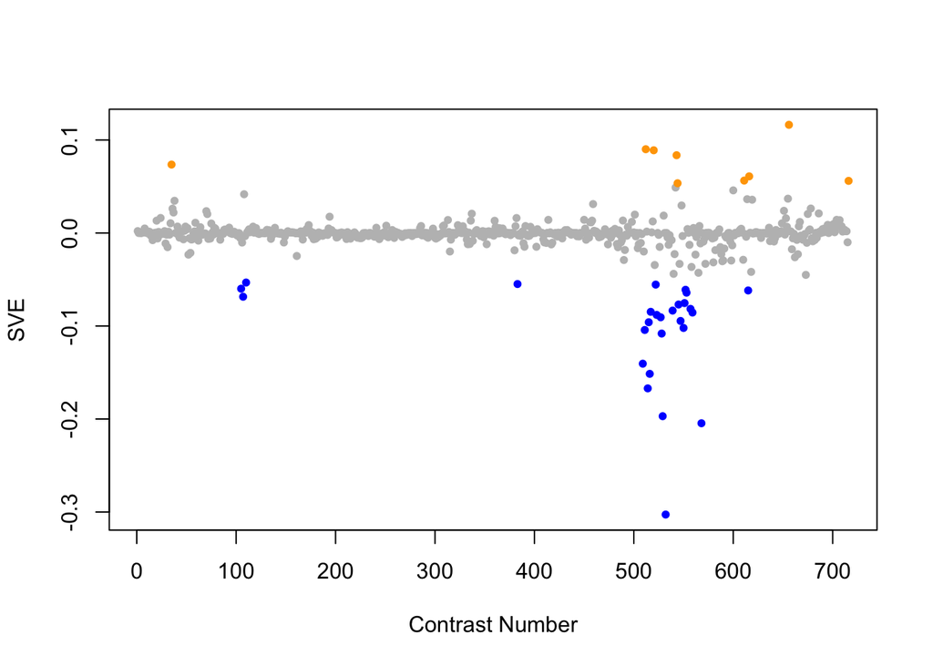

Positive SVE Contrasts:

|  | Contrast.Num | SVE | GEO.GSE | Cond.1 | Cond.2 | Mutation |
| --- | --- | --- | --- | --- | --- | --- |
| GSE16050.s1t1.vs.s0t1 | 656 | 0.12 | GSE16050 | MT_GFPp_rep1 | WT_GFPp_rep1 |  |
| GSE2180.s3t1.vs.s2t1 | 512 | 0.09 | GSE2180 | p0-3 | ms0-1 |  |
| GSE2180.s4t7.vs.s3t7 | 520 | 0.09 | GSE2180 | pp101-1 | p101-2 | pal-1(RNAi) |
| GSE2180.s4t2.vs.s2t2 | 543 | 0.08 | GSE2180 | pp23-1 | ms23-1 |  |
| GSE9665.s3t3.vs.s0t3 | 35 | 0.07 | GSE9665 | mex-3 hlh-1 230 A | mex-3 230 A | hlh-1 |
| GSE21591.s2t1.vs.s3t1 | 616 | 0.06 | GSE21591 | Input_1 | GGF_aFLAG_1 |  |
| GSE21591.s2t1.vs.s5t1 | 611 | 0.06 | GSE21591 | Input_1 | aFLAG_1 |  |
| GSE10787B.s1t1.vs.s0t1 | 716 | 0.06 | GSE10787 | Microwave (de_Pomerai_10_E5_C.Elegans) | Sham (de_Pomerai_1_S1_C.Elegans) |  |
| GSE2180.s4t2.vs.s3t2 | 544 | 0.05 | GSE2180 | pp23-1 | p23-2 | pal-1(RNAi) |

Negative SVE Contrasts:

|  | Contrast.Num | SVE | GEO.GSE | Cond.1 | Cond.2 | Mutation |
| --- | --- | --- | --- | --- | --- | --- |
| GSE2180.s4t9.vs.s3t9 | 532 | -0.30 | GSE2180 | pp143-1 | p143-2 | pal-1(RNAi) |
| GSE2180.s4t6.vs.s3t6 | 568 | -0.20 | GSE2180 | pp83-1 | p83-2 | pal-1(RNAi) |
| GSE2180.s4t9.vs.s1t9 | 529 | -0.20 | GSE2180 | pp143-1 | 143L | pie-1(zu154);pal-1(RNAi) |
| GSE2180.s4t1.vs.s3t1 | 514 | -0.17 | GSE2180 | pp0-1 | p0-3 | pal-1(RNAi) |
| GSE2180.s3t7.vs.s1t7 | 516 | -0.15 | GSE2180 | p101-2 | 101G | pie-1(zu154) |
| GSE2180.s2t1.vs.s1t1 | 509 | -0.14 | GSE2180 | ms0-1 | 00B | mex-3(zu155);skn-1(RNAi) |
| GSE2180.s3t9.vs.s1t9 | 528 | -0.11 | GSE2180 | p143-2 | 143L | pie-1(zu154) |
| GSE2180.s4t1.vs.s1t1 | 511 | -0.10 | GSE2180 | pp0-1 | 00B | pie-1(zu154);pal-1(RNAi) |
| GSE2180.s4t3.vs.s3t3 | 550 | -0.10 | GSE2180 | pp41-1 | p41-2 | pal-1(RNAi) |
| GSE2180.s2t7.vs.s1t7 | 515 | -0.10 | GSE2180 | ms101-2 | 101G | mex-3(zu155);skn-1(RNAi) |
| GSE2180.s4t3.vs.s1t3 | 547 | -0.09 | GSE2180 | pp41-1 | 41D | pie-1(zu154);pal-1(RNAi) |
| GSE2180.s2t9.vs.s1t9 | 527 | -0.09 | GSE2180 | ms143-2 | 143L | mex-3(zu155);skn-1(RNAi) |
| GSE2180.s4t8.vs.s1t8 | 523 | -0.09 | GSE2180 | pp122-1 | 122-1 | pie-1(zu154);pal-1(RNAi) |
| GSE2180.s4t5.vs.s1t5 | 559 | -0.09 | GSE2180 | pp66-1 | 66-4 | pie-1(zu154);pal-1(RNAi) |
| GSE2180.s4t7.vs.s1t7 | 517 | -0.08 | GSE2180 | pp101-1 | 101G | pie-1(zu154);pal-1(RNAi) |
| GSE2180.s2t2.vs.s1t2 | 539 | -0.08 | GSE2180 | ms23-1 | 23-1 | mex-3(zu155);skn-1(RNAi) |
| GSE2180.s2t5.vs.s1t5 | 557 | -0.08 | GSE2180 | ms66-3 | 66-4 | mex-3(zu155);skn-1(RNAi) |
| GSE2180.s2t3.vs.s1t3 | 545 | -0.08 | GSE2180 | ms41-1 | 41D | mex-3(zu155);skn-1(RNAi) |
| GSE2180.s2t4.vs.s1t4 | 551 | -0.08 | GSE2180 | ms53-4 | 53-1 | mex-3(zu155);skn-1(RNAi) |
| GSE54513.s4t1.vs.s1t1 | 107 | -0.07 | GSE54513 | spe-9 OMA-1 IP rep1 | fog-1 input rep1 |  |
| GSE2180.s4t4.vs.s1t4 | 553 | -0.06 | GSE2180 | pp53-1 | 53-1 | pie-1(zu154);pal-1(RNAi) |
| GSE21591.s1t1.vs.s4t1 | 615 | -0.06 | GSE21591 | N2_aFLAG_1 | aMYC_1 |  |
| GSE2180.s3t4.vs.s1t4 | 552 | -0.06 | GSE2180 | p53-2 | 53-1 | pie-1(zu154) |
| GSE54513.s2t1.vs.s1t1 | 105 | -0.06 | GSE54513 | fog-1 OMA-1 IP rep1 | fog-1 input rep1 |  |
| GSE2180.s3t8.vs.s1t8 | 522 | -0.06 | GSE2180 | p122-2 | 122-1 | pie-1(zu154) |
| GSE34113.s1t1.vs.s0t1 | 383 | -0.05 | GSE34113 | tdp-1(ok803) | wild-type 1 | tdp-1 |
| GSE54513.s4t1.vs.s3t1 | 110 | -0.05 | GSE54513 | spe-9 OMA-1 IP rep1 | spe-9 input rep1 |  |

$~$

#### Contrast SVE, Up-Regulated Genes Only:

Calculating SVE for up-regulated and down-regulated genes separately may be more informative in many cases than projecting the up- and down- gene sets together. This is due to the fact that the weight distribution of many modules is highly skewed, indicating that only one of the hemi-modules may be biologically meaningful (i.e., a set of genes are strongly correlated by only a few genes (or none) are strongly anti-correlated to that set.)

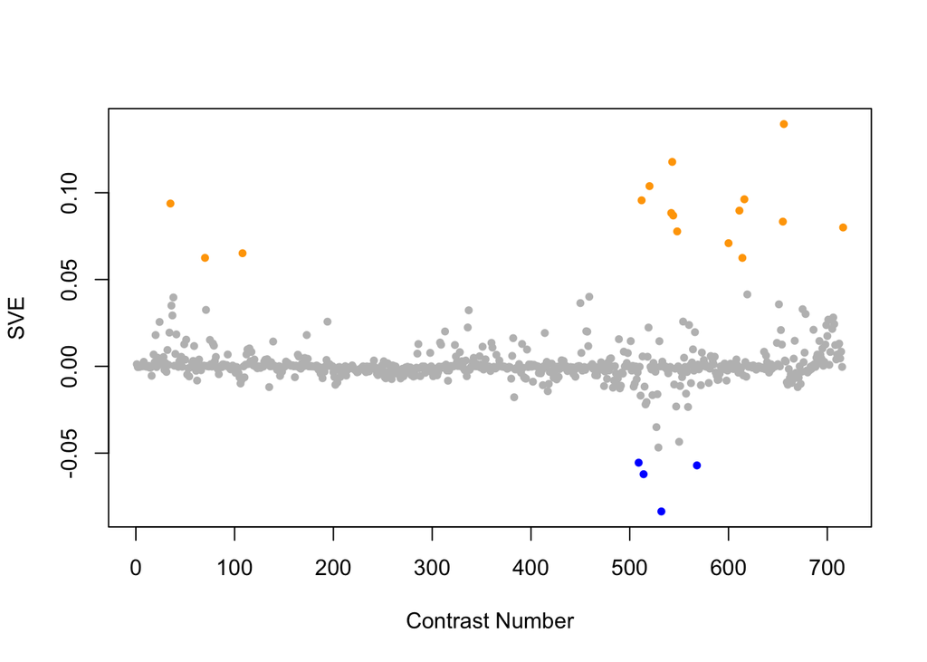

Positive SVE Contrasts:

|  | Contrast.Num | SVE | GEO.GSE | Cond.1 | Cond.2 | Mutation |
| --- | --- | --- | --- | --- | --- | --- |
| GSE16050.s1t1.vs.s0t1 | 656 | 0.14 | GSE16050 | MT_GFPp_rep1 | WT_GFPp_rep1 |  |
| GSE2180.s4t2.vs.s2t2 | 543 | 0.12 | GSE2180 | pp23-1 | ms23-1 |  |
| GSE2180.s4t7.vs.s3t7 | 520 | 0.10 | GSE2180 | pp101-1 | p101-2 | pal-1(RNAi) |
| GSE21591.s2t1.vs.s3t1 | 616 | 0.10 | GSE21591 | Input_1 | GGF_aFLAG_1 |  |
| GSE2180.s3t1.vs.s2t1 | 512 | 0.10 | GSE2180 | p0-3 | ms0-1 |  |
| GSE9665.s3t3.vs.s0t3 | 35 | 0.09 | GSE9665 | mex-3 hlh-1 230 A | mex-3 230 A | hlh-1 |
| GSE21591.s2t1.vs.s5t1 | 611 | 0.09 | GSE21591 | Input_1 | aFLAG_1 |  |
| GSE2180.s3t2.vs.s2t2 | 542 | 0.09 | GSE2180 | p23-2 | ms23-1 |  |
| GSE2180.s4t2.vs.s3t2 | 544 | 0.09 | GSE2180 | pp23-1 | p23-2 | pal-1(RNAi) |
| GSE16050.s1t2.vs.s0t2 | 655 | 0.08 | GSE16050 | MT_GFPm_rep1 | WT_GFPm_rep1 |  |
| GSE10787B.s1t1.vs.s0t1 | 716 | 0.08 | GSE10787 | Microwave (de_Pomerai_10_E5_C.Elegans) | Sham (de_Pomerai_1_S1_C.Elegans) |  |
| GSE2180.s3t3.vs.s2t3 | 548 | 0.08 | GSE2180 | p41-2 | ms41-1 |  |
| GSE2180.s4t2.vs.s4t1 | 600 | 0.07 | GSE2180 | pp23-1 | pp0-1 |  |
| GSE54513.s3t1.vs.s2t1 | 108 | 0.07 | GSE54513 | spe-9 input rep1 | fog-1 OMA-1 IP rep1 |  |
| GSE8462.s1t2.vs.s1t1 | 70 | 0.06 | GSE8462 | 24 hr muscle, biological rep 1 | 0 hr muscle, biological rep 1 |  |
| GSE21591.s2t1.vs.s4t1 | 614 | 0.06 | GSE21591 | Input_1 | aMYC_1 |  |

Negative SVE Contrasts:

|  | Contrast.Num | SVE | GEO.GSE | Cond.1 | Cond.2 | Mutation |
| --- | --- | --- | --- | --- | --- | --- |
| GSE2180.s4t9.vs.s3t9 | 532 | -0.08 | GSE2180 | pp143-1 | p143-2 | pal-1(RNAi) |
| GSE2180.s4t1.vs.s3t1 | 514 | -0.06 | GSE2180 | pp0-1 | p0-3 | pal-1(RNAi) |
| GSE2180.s4t6.vs.s3t6 | 568 | -0.06 | GSE2180 | pp83-1 | p83-2 | pal-1(RNAi) |
| GSE2180.s2t1.vs.s1t1 | 509 | -0.06 | GSE2180 | ms0-1 | 00B | mex-3(zu155);skn-1(RNAi) |
| GSE2180.s4t9.vs.s1t9 | 529 | -0.05 | GSE2180 | pp143-1 | 143L | pie-1(zu154);pal-1(RNAi) |

$~$

#### Contrast SVE, Down-Regulated Genes Only:

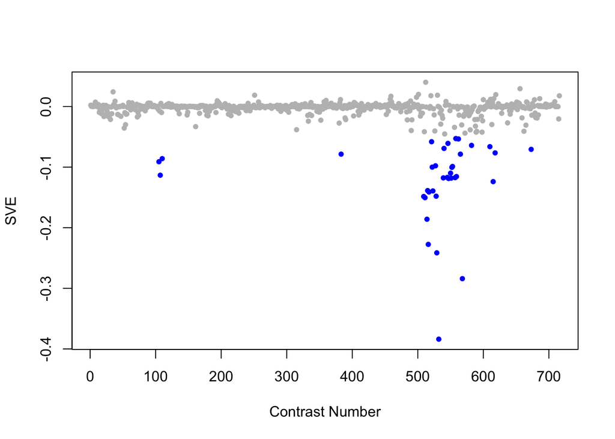

Positive SVE Contrasts:

|  | Contrast.Num | SVE | GEO.GSE | Cond.1 | Cond.2 | Mutation |
| --- | --- | --- | --- | --- | --- | --- |
| GSE2180.s3t1.vs.s2t1 | 512 | 0.04 | GSE2180 | p0-3 | ms0-1 |  |
| GSE16050.s1t1.vs.s0t1 | 656 | 0.03 | GSE16050 | MT_GFPp_rep1 | WT_GFPp_rep1 |  |
| GSE9665.s3t3.vs.s0t3 | 35 | 0.02 | GSE9665 | mex-3 hlh-1 230 A | mex-3 230 A | hlh-1 |
| GSE23013.s1t1.vs.s0t1 | 501 | 0.02 | GSE23013 | young adult_24hr Toluene exposure_rep1 | young adult_not exposed_rep1 |  |
| GSE21467.s1t1.vs.s0t1 | 619 | 0.02 | GSE21467 | ung-1, biological rep1 | wild type N2, biological rep1 | ung-1 |

Negative SVE Contrasts:

|  | Contrast.Num | SVE | GEO.GSE | Cond.1 | Cond.2 | Mutation |
| --- | --- | --- | --- | --- | --- | --- |
| GSE2180.s4t9.vs.s3t9 | 532 | -0.38 | GSE2180 | pp143-1 | p143-2 | pal-1(RNAi) |
| GSE2180.s4t6.vs.s3t6 | 568 | -0.28 | GSE2180 | pp83-1 | p83-2 | pal-1(RNAi) |
| GSE2180.s4t9.vs.s1t9 | 529 | -0.24 | GSE2180 | pp143-1 | 143L | pie-1(zu154);pal-1(RNAi) |
| GSE2180.s3t7.vs.s1t7 | 516 | -0.23 | GSE2180 | p101-2 | 101G | pie-1(zu154) |
| GSE2180.s4t1.vs.s3t1 | 514 | -0.19 | GSE2180 | pp0-1 | p0-3 | pal-1(RNAi) |
| GSE2180.s4t1.vs.s1t1 | 511 | -0.15 | GSE2180 | pp0-1 | 00B | pie-1(zu154);pal-1(RNAi) |
| GSE2180.s2t1.vs.s1t1 | 509 | -0.15 | GSE2180 | ms0-1 | 00B | mex-3(zu155);skn-1(RNAi) |
| GSE2180.s3t9.vs.s1t9 | 528 | -0.15 | GSE2180 | p143-2 | 143L | pie-1(zu154) |
| GSE2180.s4t7.vs.s1t7 | 517 | -0.14 | GSE2180 | pp101-1 | 101G | pie-1(zu154);pal-1(RNAi) |
| GSE2180.s4t8.vs.s1t8 | 523 | -0.14 | GSE2180 | pp122-1 | 122-1 | pie-1(zu154);pal-1(RNAi) |
| GSE2180.s2t7.vs.s1t7 | 515 | -0.14 | GSE2180 | ms101-2 | 101G | mex-3(zu155);skn-1(RNAi) |
| GSE21591.s1t1.vs.s4t1 | 615 | -0.12 | GSE21591 | N2_aFLAG_1 | aMYC_1 |  |
| GSE2180.s4t3.vs.s1t3 | 547 | -0.12 | GSE2180 | pp41-1 | 41D | pie-1(zu154);pal-1(RNAi) |
| GSE2180.s2t4.vs.s1t4 | 551 | -0.12 | GSE2180 | ms53-4 | 53-1 | mex-3(zu155);skn-1(RNAi) |
| GSE2180.s2t2.vs.s1t2 | 539 | -0.12 | GSE2180 | ms23-1 | 23-1 | mex-3(zu155);skn-1(RNAi) |
| GSE2180.s2t5.vs.s1t5 | 557 | -0.12 | GSE2180 | ms66-3 | 66-4 | mex-3(zu155);skn-1(RNAi) |
| GSE2180.s2t3.vs.s1t3 | 545 | -0.12 | GSE2180 | ms41-1 | 41D | mex-3(zu155);skn-1(RNAi) |
| GSE2180.s4t5.vs.s1t5 | 559 | -0.12 | GSE2180 | pp66-1 | 66-4 | pie-1(zu154);pal-1(RNAi) |
| GSE54513.s4t1.vs.s1t1 | 107 | -0.11 | GSE54513 | spe-9 OMA-1 IP rep1 | fog-1 input rep1 |  |
| GSE2180.s4t3.vs.s3t3 | 550 | -0.11 | GSE2180 | pp41-1 | p41-2 | pal-1(RNAi) |
| GSE2180.s3t4.vs.s1t4 | 552 | -0.10 | GSE2180 | p53-2 | 53-1 | pie-1(zu154) |
| GSE2180.s3t8.vs.s1t8 | 522 | -0.10 | GSE2180 | p122-2 | 122-1 | pie-1(zu154) |
| GSE2180.s4t4.vs.s1t4 | 553 | -0.10 | GSE2180 | pp53-1 | 53-1 | pie-1(zu154);pal-1(RNAi) |
| GSE2180.s2t9.vs.s1t9 | 527 | -0.10 | GSE2180 | ms143-2 | 143L | mex-3(zu155);skn-1(RNAi) |
| GSE54513.s2t1.vs.s1t1 | 105 | -0.09 | GSE54513 | fog-1 OMA-1 IP rep1 | fog-1 input rep1 |  |
| GSE54513.s4t1.vs.s3t1 | 110 | -0.09 | GSE54513 | spe-9 OMA-1 IP rep1 | spe-9 input rep1 |  |
| GSE34113.s1t1.vs.s0t1 | 383 | -0.08 | GSE34113 | tdp-1(ok803) | wild-type 1 | tdp-1 |
| GSE2180.s4t6.vs.s1t6 | 565 | -0.08 | GSE2180 | pp83-1 | 83-1 | pie-1(zu154);pal-1(RNAi) |
| GSE21591.s1t1.vs.s2t1 | 618 | -0.08 | GSE21591 | N2_aFLAG_1 | Input_1 |  |
| GSE14640B.s1t1.vs.s0t1 | 673 | -0.07 | GSE14640 | XX_DPY27-N_042807_A | XX_WT-N_080307_A |  |
| GSE2180.s3t2.vs.s1t2 | 540 | -0.07 | GSE2180 | p23-2 | 23-1 | pie-1(zu154) |
| GSE21591.s3t1.vs.s5t1 | 610 | -0.07 | GSE21591 | GGF_aFLAG_1 | aFLAG_1 |  |
| GSE2180.s2t2.vs.s2t1 | 582 | -0.06 | GSE2180 | ms23-1 | ms0-1 |  |
| GSE2180.s3t3.vs.s1t3 | 546 | -0.06 | GSE2180 | p41-2 | 41D | pie-1(zu154) |
| GSE2180.s2t8.vs.s1t8 | 521 | -0.06 | GSE2180 | ms122-1 | 122-1 | mex-3(zu155);skn-1(RNAi) |
| GSE2180.s4t5.vs.s3t5 | 562 | -0.05 | GSE2180 | pp66-1 | p66-1 | pal-1(RNAi) |
| GSE2180.s3t5.vs.s1t5 | 558 | -0.05 | GSE2180 | p66-1 | 66-4 | pie-1(zu154) |

$~$

$~$

#### GO Term Enrichment:

This analysis tests each hemi-module for enrichment of specific GO terms. Only gene-level annotations (e.g., as would be found on the gene’s page in Wormbase) are tested - the hierarchical structure of the GO ontology is not taken into account.

*Note: At least the top two most enriched terms from each GO domain (BP/MF/CC) are shown, even when not statistically significant.*

##### Enriched GO terms: Hemi-module A

| ID | GO.Term | GO Domain | Raw p-value | Adj p-value |
| --- | --- | --- | --- | --- |
| [GO_0006412](http://amigo.geneontology.org/amigo/term/GO:0006412) | translation | BP | 3.21e-20 | 1.17e-16 |
| [GO_0015986](http://amigo.geneontology.org/amigo/term/GO:0015986) | ATP synthesis coupled proton transport | BP | 2.63e-13 | 3.77e-10 |
| [GO_0043161](http://amigo.geneontology.org/amigo/term/GO:0043161) | proteasome-mediated ubiquitin-dependent protein catabolic process | BP | 3.11e-13 | 3.77e-10 |
| [GO_0006099](http://amigo.geneontology.org/amigo/term/GO:0006099) | tricarboxylic acid cycle | BP | 1.32e-11 | 1.21e-08 |
| [GO_0055114](http://amigo.geneontology.org/amigo/term/GO:0055114) | oxidation-reduction process | BP | 1.81e-10 | 1.32e-07 |
| [GO_0006457](http://amigo.geneontology.org/amigo/term/GO:0006457) | protein folding | BP | 6.28e-10 | 3.81e-07 |
| [GO_0006413](http://amigo.geneontology.org/amigo/term/GO:0006413) | translational initiation | BP | 2.88e-09 | 1.50e-06 |
| [GO_0006120](http://amigo.geneontology.org/amigo/term/GO:0006120) | mitochondrial electron transport, NADH to ubiquinone | BP | 3.70e-09 | 1.69e-06 |
| [GO_0001732](http://amigo.geneontology.org/amigo/term/GO:0001732) | formation of cytoplasmic translation initiation complex | BP | 9.68e-09 | 3.52e-06 |
| [GO_0002183](http://amigo.geneontology.org/amigo/term/GO:0002183) | cytoplasmic translational initiation | BP | 9.68e-09 | 3.52e-06 |
| [GO_0008340](http://amigo.geneontology.org/amigo/term/GO:0008340) | determination of adult lifespan | BP | 1.40e-08 | 4.64e-06 |
| [GO_0010498](http://amigo.geneontology.org/amigo/term/GO:0010498) | proteasomal protein catabolic process | BP | 1.89e-08 | 5.69e-06 |
| [GO_0006754](http://amigo.geneontology.org/amigo/term/GO:0006754) | ATP biosynthetic process | BP | 2.03e-08 | 5.69e-06 |
| [GO_0010499](http://amigo.geneontology.org/amigo/term/GO:0010499) | proteasomal ubiquitin-independent protein catabolic process | BP | 1.00e-07 | 2.61e-05 |
| [GO_0006418](http://amigo.geneontology.org/amigo/term/GO:0006418) | tRNA aminoacylation for protein translation | BP | 1.67e-07 | 4.07e-05 |
| [GO_0006414](http://amigo.geneontology.org/amigo/term/GO:0006414) | translational elongation | BP | 1.06e-06 | 2.42e-04 |
| [GO_0007186](http://amigo.geneontology.org/amigo/term/GO:0007186) | G protein-coupled receptor signaling pathway | BP | 2.21e-06 | 4.73e-04 |
| [GO_0042176](http://amigo.geneontology.org/amigo/term/GO:0042176) | regulation of protein catabolic process | BP | 5.91e-06 | 1.13e-03 |
| [GO_0045899](http://amigo.geneontology.org/amigo/term/GO:0045899) | positive regulation of RNA polymerase II transcriptional preinitiation complex assembly | BP | 5.91e-06 | 1.13e-03 |
| [GO_0030433](http://amigo.geneontology.org/amigo/term/GO:0030433) | ubiquitin-dependent ERAD pathway | BP | 6.20e-06 | 1.13e-03 |
| [GO_0006511](http://amigo.geneontology.org/amigo/term/GO:0006511) | ubiquitin-dependent protein catabolic process | BP | 1.39e-05 | 2.41e-03 |
| [GO_0007017](http://amigo.geneontology.org/amigo/term/GO:0007017) | microtubule-based process | BP | 2.36e-05 | 3.90e-03 |
| [GO_0006104](http://amigo.geneontology.org/amigo/term/GO:0006104) | succinyl-CoA metabolic process | BP | 6.39e-05 | 9.32e-03 |
| [GO_0042776](http://amigo.geneontology.org/amigo/term/GO:0042776) | mitochondrial ATP synthesis coupled proton transport | BP | 6.39e-05 | 9.32e-03 |
| [GO_1901800](http://amigo.geneontology.org/amigo/term/GO:1901800) | positive regulation of proteasomal protein catabolic process | BP | 6.39e-05 | 9.32e-03 |
| [GO_0006096](http://amigo.geneontology.org/amigo/term/GO:0006096) | glycolytic process | BP | 1.17e-04 | 1.53e-02 |
| [GO_0050790](http://amigo.geneontology.org/amigo/term/GO:0050790) | regulation of catalytic activity | BP | 1.17e-04 | 1.53e-02 |
| [GO_0006164](http://amigo.geneontology.org/amigo/term/GO:0006164) | purine nucleotide biosynthetic process | BP | 1.18e-04 | 1.53e-02 |
| [GO_0006165](http://amigo.geneontology.org/amigo/term/GO:0006165) | nucleoside diphosphate phosphorylation | BP | 1.57e-04 | 1.97e-02 |
| [GO_0009792](http://amigo.geneontology.org/amigo/term/GO:0009792) | embryo development ending in birth or egg hatching | BP | 1.87e-04 | 2.27e-02 |

[output cut: 130 more lines]

##### Enriched GO terms: Hemi-module B

| ID | GO.Term | GO Domain | Raw p-value | Adj p-value |
| --- | --- | --- | --- | --- |
| [GO_0000448](http://amigo.geneontology.org/amigo/term/GO:0000448) | cleavage in ITS2 between 5.8S rRNA and LSU-rRNA of tricistronic rRNA transcript (SSU-rRNA, 5.8S rRNA, LSU-rRNA) | BP | 7.48e-04 | 1.00e+00 |
| [GO_0071569](http://amigo.geneontology.org/amigo/term/GO:0071569) | protein ufmylation | BP | 1.50e-03 | 1.00e+00 |
| [GO_0051731](http://amigo.geneontology.org/amigo/term/GO:0051731) | polynucleotide 5’-hydroxyl-kinase activity | MF | 1.50e-03 | 1.00e+00 |
| [GO_0003735](http://amigo.geneontology.org/amigo/term/GO:0003735) | structural constituent of ribosome | MF | 3.97e-03 | 1.00e+00 |
| [GO_0005840](http://amigo.geneontology.org/amigo/term/GO:0005840) | ribosome | CC | 4.40e-03 | 1.00e+00 |
| [GO_0030286](http://amigo.geneontology.org/amigo/term/GO:0030286) | dynein complex | CC | 5.97e-03 | 1.00e+00 |

$~$

$~$

#### Tissue Enrichment:

This analysis tests each hemi-module for enrichment of genes associated with anatomy terms. Negative enrichment scores indicate fewer hemi-module genes than expected by random chance were associated with the anatomy term in question.

##### Enriched tissues: Hemi-module A

| ID | Anatomy.Term | Definition | Raw p-value | Adj p-value |
| --- | --- | --- | --- | --- |
| [WBbt_0003681](https://wormbase.org/species/all/anatomy_term/WBbt:0003681) | pharynx | the feeding organ, a neuro-muscular pump in the head of the animal, used to ingest food, bacteria suspended in liquid, filter them out, grind them up and transport posteriorly into the instestine. | 4.56e-20 | 1.11e-16 |
| [WBbt_0005813](https://wormbase.org/species/all/anatomy_term/WBbt:0005813) | body wall musculature | Longitudinal bands of muscle cells surrounding animal body, with one band running in each quadrant of the body, regulated contraction and relaxation of these muscles cause locomotion. | 1.36e-18 | 1.66e-15 |
| [WBbt_0005772](https://wormbase.org/species/all/anatomy_term/WBbt:0005772) | intestine | A chain of very large cuboidal cells forming a wide central lumen in which food arrives from the posterior pharynx, is digested, and from which waste products proceed to the rectum. Intestinal rings f… | 1.03e-12 | 8.38e-10 |
| [WBbt_0005747](https://wormbase.org/species/all/anatomy_term/WBbt:0005747) | reproductive system |  | 2.43e-12 | 1.48e-09 |
| [WBbt_0004292](https://wormbase.org/species/all/anatomy_term/WBbt:0004292) | anal depressor muscle | a single, H-shaped cell which lies just above the anus and connects the roof of the anal canal to the dorsal bodywall; its contractions act to increase the size of the anal opening by lifting the roof… | 2.65e-10 | 1.29e-07 |
| [WBbt_0003822](https://wormbase.org/species/all/anatomy_term/WBbt:0003822) | mu_int_R | right intestinal muscle cell, attach to intestine and body wall anterior to anus | 2.97e-09 | 1.03e-06 |
| [WBbt_0003833](https://wormbase.org/species/all/anatomy_term/WBbt:0003833) | mu_int_L | left intestinal muscle cell, attach to intestine and body wall anterior to anus | 2.97e-09 | 1.03e-06 |
| [WBbt_0005741](https://wormbase.org/species/all/anatomy_term/WBbt:0005741) | tail | posterior region, from rectum to the end | 6.56e-08 | 2.00e-05 |
| [WBbt_0005733](https://wormbase.org/species/all/anatomy_term/WBbt:0005733) | hypodermis | Epidermal layer. | 3.45e-07 | 9.32e-05 |
| [WBbt_0005735](https://wormbase.org/species/all/anatomy_term/WBbt:0005735) | nervous system | Complement of nervous tissue (neurones, nerves, receptors and support cells) serving to detect, relay and coordinate information about an animal’s internal and external environments and to initiate an… | 8.09e-06 | 1.97e-03 |
| [WBbt_0005739](https://wormbase.org/species/all/anatomy_term/WBbt:0005739) | head | anterior-most body region containing the pharynx. | 1.27e-05 | 2.80e-03 |
| [WBbt_0006748](https://wormbase.org/species/all/anatomy_term/WBbt:0006748) | vulva | female genital. | 3.86e-05 | 7.82e-03 |
| [WBbt_0005800](https://wormbase.org/species/all/anatomy_term/WBbt:0005800) | rectal epithelium | epithelium connecting intestine and anus. | 4.45e-05 | 8.33e-03 |
| [WBbt_0005821](https://wormbase.org/species/all/anatomy_term/WBbt:0005821) | vulval muscle | muscle associated with hermaphrodite vulva. | 4.97e-05 | 8.63e-03 |
| [WBbt_0005300](https://wormbase.org/species/all/anatomy_term/WBbt:0005300) | ventral cord neuron | neuron with cell body associated with the ventral nerve cord. | 7.32e-05 | 1.19e-02 |
| [WBbt_0006749](https://wormbase.org/species/all/anatomy_term/WBbt:0006749) | nerve ring | the most extensive region of neuropil in the animal, consists of a large toroidal bundle of processes. | 3.06e-04 | 4.66e-02 |
| [WBbt_0004017](https://wormbase.org/species/all/anatomy_term/WBbt:0004017) | Cell | a cellular object that consists of subcellular components, expresses genes or functions. | 3.65e-04 | 5.22e-02 |

##### Enriched tissues: Hemi-module B

No significant annotations.

$~$

$~$

#### HOMER promoter motif enrichment:

This analysis tests each hemi-module for enrichment of 108 known *C. elegans* transcription factor binding site motifs (see [108 CE motifs](https://katiepod.github.io//all.worm.motifs.html)) using the HOMER (Hypergeometric Optimization of Motif EnRichment) software (see [PMID:20513432](https://pubmed.ncbi.nlm.nih.gov/20513432)). HOMER was run using default parameters on sequences 1 kb upstream of the transcription start site.

##### Motif enrichment: Hemi-module A

Total target sequences = 313  
Total background sequences = 36108  
* - possible false positive

Rank

Motif

P-value

log P-pvalue

% of Targets

% of Background

STD(Bg STD)

Best Match/Details

Motif File

1

[figure not shown]

1e-23

-5.298e+01

21.73%

5.13%

210.4bp (357.8bp)

POL011.1_XCPE1/Jaspar(0.589)  
[More Information](https://katiepod.github.io/HomerResults/m49_a_hemi_genes.txt.out.1kb/homerResults/motif1.info.html) | [Similar Motifs Found](https://katiepod.github.io/HomerResults/m49_a_hemi_genes.txt.out.1kb/homerResults/motif1.similar.html)

[motif file (matrix)](https://katiepod.github.io/HomerResults/m49_a_hemi_genes.txt.out.1kb/homerResults/motif1.motif)

2

[figure not shown]

1e-19

-4.514e+01

60.38%

34.66%

251.7bp (382.1bp)

DPL-1(E2F)/cElegans-Adult-ChIP-Seq(modEncode)/Homer(0.791)  
[More Information](https://katiepod.github.io/HomerResults/m49_a_hemi_genes.txt.out.1kb/homerResults/motif2.info.html) | [Similar Motifs Found](https://katiepod.github.io/HomerResults/m49_a_hemi_genes.txt.out.1kb/homerResults/motif2.similar.html)

[motif file (matrix)](https://katiepod.github.io/HomerResults/m49_a_hemi_genes.txt.out.1kb/homerResults/motif2.motif)

3

[figure not shown]

1e-14

-3.353e+01

12.46%

2.63%

290.7bp (327.9bp)

lim-7/MA1441.1/Jaspar(0.748)  
[More Information](https://katiepod.github.io/HomerResults/m49_a_hemi_genes.txt.out.1kb/homerResults/motif3.info.html) | [Similar Motifs Found](https://katiepod.github.io/HomerResults/m49_a_hemi_genes.txt.out.1kb/homerResults/motif3.similar.html)

[motif file (matrix)](https://katiepod.github.io/HomerResults/m49_a_hemi_genes.txt.out.1kb/homerResults/motif3.motif)

4

[figure not shown]

1e-14

-3.236e+01

19.49%

6.37%

333.5bp (376.0bp)

SA0001.1_at_AC_acceptor/Jaspar(0.607)  
[More Information](https://katiepod.github.io/HomerResults/m49_a_hemi_genes.txt.out.1kb/homerResults/motif4.info.html) | [Similar Motifs Found](https://katiepod.github.io/HomerResults/m49_a_hemi_genes.txt.out.1kb/homerResults/motif4.similar.html)

[motif file (matrix)](https://katiepod.github.io/HomerResults/m49_a_hemi_genes.txt.out.1kb/homerResults/motif4.motif)

5

[figure not shown]

1e-13

-3.079e+01

7.99%

1.09%

311.7bp (375.0bp)

skn-1/MA0547.1/Jaspar(0.843)  
[More Information](https://katiepod.github.io/HomerResults/m49_a_hemi_genes.txt.out.1kb/homerResults/motif5.info.html) | [Similar Motifs Found](https://katiepod.github.io/HomerResults/m49_a_hemi_genes.txt.out.1kb/homerResults/motif5.similar.html)

[motif file (matrix)](https://katiepod.github.io/HomerResults/m49_a_hemi_genes.txt.out.1kb/homerResults/motif5.motif)

6

[figure not shown]

1e-13

-3.032e+01

32.91%

15.76%

272.9bp (362.1bp)

EFL-1(E2F)/cElegans-L1-EFL1-ChIP-Seq(modEncode)/Homer(0.674)  
[More Information](https://katiepod.github.io/HomerResults/m49_a_hemi_genes.txt.out.1kb/homerResults/motif6.info.html) | [Similar Motifs Found](https://katiepod.github.io/HomerResults/m49_a_hemi_genes.txt.out.1kb/homerResults/motif6.similar.html)

[motif file (matrix)](https://katiepod.github.io/HomerResults/m49_a_hemi_genes.txt.out.1kb/homerResults/motif6.motif)

7

[figure not shown]

1e-12

-2.901e+01

12.46%

3.05%

250.1bp (377.5bp)

cebp-1/MA1444.1/Jaspar(0.764)  
[More Information](https://katiepod.github.io/HomerResults/m49_a_hemi_genes.txt.out.1kb/homerResults/motif7.info.html) | [Similar Motifs Found](https://katiepod.github.io/HomerResults/m49_a_hemi_genes.txt.out.1kb/homerResults/motif7.similar.html)

[motif file (matrix)](https://katiepod.github.io/HomerResults/m49_a_hemi_genes.txt.out.1kb/homerResults/motif7.motif)

8

[figure not shown]

1e-12

-2.852e+01

46.01%

26.85%

268.6bp (371.3bp)

MF0003.1_REL_class/Jaspar(0.591)  
[More Information](https://katiepod.github.io/HomerResults/m49_a_hemi_genes.txt.out.1kb/homerResults/motif8.info.html) | [Similar Motifs Found](https://katiepod.github.io/HomerResults/m49_a_hemi_genes.txt.out.1kb/homerResults/motif8.similar.html)

[motif file (matrix)](https://katiepod.github.io/HomerResults/m49_a_hemi_genes.txt.out.1kb/homerResults/motif8.motif)

9 *

[figure not shown]

1e-11

-2.718e+01

30.99%

15.12%

293.7bp (369.9bp)

efl-1/MA0541.1/Jaspar(0.670)  
[More Information](https://katiepod.github.io/HomerResults/m49_a_hemi_genes.txt.out.1kb/homerResults/motif9.info.html) | [Similar Motifs Found](https://katiepod.github.io/HomerResults/m49_a_hemi_genes.txt.out.1kb/homerResults/motif9.similar.html)

[motif file (matrix)](https://katiepod.github.io/HomerResults/m49_a_hemi_genes.txt.out.1kb/homerResults/motif9.motif)

10 *

[figure not shown]

1e-11

-2.563e+01

15.97%

5.33%

286.6bp (355.4bp)

ceh-38/MA1699.1/Jaspar(0.725)  
[More Information](https://katiepod.github.io/HomerResults/m49_a_hemi_genes.txt.out.1kb/homerResults/motif10.info.html) | [Similar Motifs Found](https://katiepod.github.io/HomerResults/m49_a_hemi_genes.txt.out.1kb/homerResults/motif10.similar.html)

[motif file (matrix)](https://katiepod.github.io/HomerResults/m49_a_hemi_genes.txt.out.1kb/homerResults/motif10.motif)

11 *

[figure not shown]

1e-10

-2.512e+01

4.15%

0.27%

189.2bp (359.1bp)

POL010.1_DCE_S_III/Jaspar(0.600)  
[More Information](https://katiepod.github.io/HomerResults/m49_a_hemi_genes.txt.out.1kb/homerResults/motif11.info.html) | [Similar Motifs Found](https://katiepod.github.io/HomerResults/m49_a_hemi_genes.txt.out.1kb/homerResults/motif11.similar.html)

[motif file (matrix)](https://katiepod.github.io/HomerResults/m49_a_hemi_genes.txt.out.1kb/homerResults/motif11.motif)

12 *

[figure not shown]

1e-10

-2.504e+01

47.28%

29.17%

292.7bp (358.0bp)

POL008.1_DCE_S_I/Jaspar(0.635)  
[More Information](https://katiepod.github.io/HomerResults/m49_a_hemi_genes.txt.out.1kb/homerResults/motif12.info.html) | [Similar Motifs Found](https://katiepod.github.io/HomerResults/m49_a_hemi_genes.txt.out.1kb/homerResults/motif12.similar.html)

[motif file (matrix)](https://katiepod.github.io/HomerResults/m49_a_hemi_genes.txt.out.1kb/homerResults/motif12.motif)

13 *

[figure not shown]

1e-10

-2.443e+01

5.75%

0.69%

240.6bp (364.0bp)

snpc-4/MA0544.1/Jaspar(0.569)  
[More Information](https://katiepod.github.io/HomerResults/m49_a_hemi_genes.txt.out.1kb/homerResults/motif13.info.html) | [Similar Motifs Found](https://katiepod.github.io/HomerResults/m49_a_hemi_genes.txt.out.1kb/homerResults/motif13.similar.html)

[motif file (matrix)](https://katiepod.github.io/HomerResults/m49_a_hemi_genes.txt.out.1kb/homerResults/motif13.motif)

14 *

[figure not shown]

1e-10

-2.423e+01

36.10%

19.95%

284.0bp (384.3bp)

ceh-48/MA0921.1/Jaspar(0.825)  
[More Information](https://katiepod.github.io/HomerResults/m49_a_hemi_genes.txt.out.1kb/homerResults/motif14.info.html) | [Similar Motifs Found](https://katiepod.github.io/HomerResults/m49_a_hemi_genes.txt.out.1kb/homerResults/motif14.similar.html)

[motif file (matrix)](https://katiepod.github.io/HomerResults/m49_a_hemi_genes.txt.out.1kb/homerResults/motif14.motif)

15 *

[figure not shown]

1e-10

-2.353e+01

8.63%

1.81%

263.7bp (358.6bp)

POL010.1_DCE_S_III/Jaspar(0.558)  
[More Information](https://katiepod.github.io/HomerResults/m49_a_hemi_genes.txt.out.1kb/homerResults/motif15.info.html) | [Similar Motifs Found](https://katiepod.github.io/HomerResults/m49_a_hemi_genes.txt.out.1kb/homerResults/motif15.similar.html)

[motif file (matrix)](https://katiepod.github.io/HomerResults/m49_a_hemi_genes.txt.out.1kb/homerResults/motif15.motif)

16 *

[figure not shown]

1e-9

-2.243e+01

5.43%

0.68%

261.3bp (258.7bp)

fkh-9/MA1440.1/Jaspar(0.592)  
[More Information](https://katiepod.github.io/HomerResults/m49_a_hemi_genes.txt.out.1kb/homerResults/motif16.info.html) | [Similar Motifs Found](https://katiepod.github.io/HomerResults/m49_a_hemi_genes.txt.out.1kb/homerResults/motif16.similar.html)

[motif file (matrix)](https://katiepod.github.io/HomerResults/m49_a_hemi_genes.txt.out.1kb/homerResults/motif16.motif)

17 *

[figure not shown]

1e-9

-2.232e+01

12.78%

4.01%

263.0bp (369.4bp)

EFL-1(E2F)/cElegans-L1-EFL1-ChIP-Seq(modEncode)/Homer(0.717)  
[More Information](https://katiepod.github.io/HomerResults/m49_a_hemi_genes.txt.out.1kb/homerResults/motif17.info.html) | [Similar Motifs Found](https://katiepod.github.io/HomerResults/m49_a_hemi_genes.txt.out.1kb/homerResults/motif17.similar.html)

[motif file (matrix)](https://katiepod.github.io/HomerResults/m49_a_hemi_genes.txt.out.1kb/homerResults/motif17.motif)

18 *

[figure not shown]

1e-9

-2.210e+01

22.68%

10.35%

273.6bp (338.4bp)

POL012.1_TATA-Box/Jaspar(0.539)  
[More Information](https://katiepod.github.io/HomerResults/m49_a_hemi_genes.txt.out.1kb/homerResults/motif18.info.html) | [Similar Motifs Found](https://katiepod.github.io/HomerResults/m49_a_hemi_genes.txt.out.1kb/homerResults/motif18.similar.html)

[motif file (matrix)](https://katiepod.github.io/HomerResults/m49_a_hemi_genes.txt.out.1kb/homerResults/motif18.motif)

19 *

[figure not shown]

1e-9

-2.209e+01

11.82%

3.52%

267.3bp (350.2bp)

EGL-5(Homeobox)/cElegans-L3-EGL5-ChIP-Seq(modEncode)/Homer(0.591)  
[More Information](https://katiepod.github.io/HomerResults/m49_a_hemi_genes.txt.out.1kb/homerResults/motif19.info.html) | [Similar Motifs Found](https://katiepod.github.io/HomerResults/m49_a_hemi_genes.txt.out.1kb/homerResults/motif19.similar.html)

[motif file (matrix)](https://katiepod.github.io/HomerResults/m49_a_hemi_genes.txt.out.1kb/homerResults/motif19.motif)

20 *

[figure not shown]

1e-9

-2.186e+01

33.23%

18.38%

273.0bp (356.5bp)

lim-7/MA1441.1/Jaspar(0.702)  
[More Information](https://katiepod.github.io/HomerResults/m49_a_hemi_genes.txt.out.1kb/homerResults/motif20.info.html) | [Similar Motifs Found](https://katiepod.github.io/HomerResults/m49_a_hemi_genes.txt.out.1kb/homerResults/motif20.similar.html)

[motif file (matrix)](https://katiepod.github.io/HomerResults/m49_a_hemi_genes.txt.out.1kb/homerResults/motif20.motif)

21 *

[figure not shown]

1e-9

-2.179e+01

4.79%

0.53%

295.7bp (305.1bp)

POL008.1_DCE_S_I/Jaspar(0.549)  
[More Information](https://katiepod.github.io/HomerResults/m49_a_hemi_genes.txt.out.1kb/homerResults/motif21.info.html) | [Similar Motifs Found](https://katiepod.github.io/HomerResults/m49_a_hemi_genes.txt.out.1kb/homerResults/motif21.similar.html)

[motif file (matrix)](https://katiepod.github.io/HomerResults/m49_a_hemi_genes.txt.out.1kb/homerResults/motif21.motif)

22 *

[figure not shown]

1e-9

-2.159e+01

4.15%

0.36%

194.0bp (304.2bp)

EGL-5(Homeobox)/cElegans-L3-EGL5-ChIP-Seq(modEncode)/Homer(0.563)  
[More Information](https://katiepod.github.io/HomerResults/m49_a_hemi_genes.txt.out.1kb/homerResults/motif22.info.html) | [Similar Motifs Found](https://katiepod.github.io/HomerResults/m49_a_hemi_genes.txt.out.1kb/homerResults/motif22.similar.html)

[motif file (matrix)](https://katiepod.github.io/HomerResults/m49_a_hemi_genes.txt.out.1kb/homerResults/motif22.motif)

23 *

[figure not shown]

1e-9

-2.153e+01

14.06%

4.86%

261.1bp (328.2bp)

MF0010.1_Homeobox_class/Jaspar(0.759)  
[More Information](https://katiepod.github.io/HomerResults/m49_a_hemi_genes.txt.out.1kb/homerResults/motif23.info.html) | [Similar Motifs Found](https://katiepod.github.io/HomerResults/m49_a_hemi_genes.txt.out.1kb/homerResults/motif23.similar.html)

[motif file (matrix)](https://katiepod.github.io/HomerResults/m49_a_hemi_genes.txt.out.1kb/homerResults/motif23.motif)

24 *

[figure not shown]

1e-9

-2.132e+01

4.79%

0.55%

279.1bp (361.6bp)

efl-1/MA0541.1/Jaspar(0.623)  
[More Information](https://katiepod.github.io/HomerResults/m49_a_hemi_genes.txt.out.1kb/homerResults/motif24.info.html) | [Similar Motifs Found](https://katiepod.github.io/HomerResults/m49_a_hemi_genes.txt.out.1kb/homerResults/motif24.similar.html)

[motif file (matrix)](https://katiepod.github.io/HomerResults/m49_a_hemi_genes.txt.out.1kb/homerResults/motif24.motif)

25 *

[figure not shown]

1e-9

-2.119e+01

1.92%

0.02%

282.5bp (183.6bp)

lin-14/MA0261.1/Jaspar(0.640)  
[More Information](https://katiepod.github.io/HomerResults/m49_a_hemi_genes.txt.out.1kb/homerResults/motif25.info.html) | [Similar Motifs Found](https://katiepod.github.io/HomerResults/m49_a_hemi_genes.txt.out.1kb/homerResults/motif25.similar.html)

[motif file (matrix)](https://katiepod.github.io/HomerResults/m49_a_hemi_genes.txt.out.1kb/homerResults/motif25.motif)

26 *

[figure not shown]

1e-9

-2.078e+01

20.45%

9.11%

281.1bp (318.1bp)

LIN-39(Homeobox)/cElegans.L3-LIN39-ChIP-Seq(modEncode)/Homer(0.618)  
[More Information](https://katiepod.github.io/HomerResults/m49_a_hemi_genes.txt.out.1kb/homerResults/motif26.info.html) | [Similar Motifs Found](https://katiepod.github.io/HomerResults/m49_a_hemi_genes.txt.out.1kb/homerResults/motif26.similar.html)

[motif file (matrix)](https://katiepod.github.io/HomerResults/m49_a_hemi_genes.txt.out.1kb/homerResults/motif26.motif)

27 *

[figure not shown]

1e-8

-2.065e+01

3.83%

0.32%

220.5bp (369.2bp)

POL004.1_CCAAT-box/Jaspar(0.481)  
[More Information](https://katiepod.github.io/HomerResults/m49_a_hemi_genes.txt.out.1kb/homerResults/motif27.info.html) | [Similar Motifs Found](https://katiepod.github.io/HomerResults/m49_a_hemi_genes.txt.out.1kb/homerResults/motif27.similar.html)

[motif file (matrix)](https://katiepod.github.io/HomerResults/m49_a_hemi_genes.txt.out.1kb/homerResults/motif27.motif)

28 *

[figure not shown]

1e-8

-2.062e+01

26.52%

13.53%

284.6bp (338.1bp)

POL002.1_INR/Jaspar(0.549)  
[More Information](https://katiepod.github.io/HomerResults/m49_a_hemi_genes.txt.out.1kb/homerResults/motif28.info.html) | [Similar Motifs Found](https://katiepod.github.io/HomerResults/m49_a_hemi_genes.txt.out.1kb/homerResults/motif28.similar.html)

[motif file (matrix)](https://katiepod.github.io/HomerResults/m49_a_hemi_genes.txt.out.1kb/homerResults/motif28.motif)

29 *

[figure not shown]

1e-8

-1.924e+01

1.92%

0.03%

300.9bp (494.0bp)

PL0016.1_ref-1/Jaspar(0.630)  
[More Information](https://katiepod.github.io/HomerResults/m49_a_hemi_genes.txt.out.1kb/homerResults/motif29.info.html) | [Similar Motifs Found](https://katiepod.github.io/HomerResults/m49_a_hemi_genes.txt.out.1kb/homerResults/motif29.similar.html)

[motif file (matrix)](https://katiepod.github.io/HomerResults/m49_a_hemi_genes.txt.out.1kb/homerResults/motif29.motif)

30 *

[figure not shown]

1e-8

-1.890e+01

3.51%

0.30%

328.3bp (296.0bp)

blmp-1/MA0537.1/Jaspar(0.650)  
[More Information](https://katiepod.github.io/HomerResults/m49_a_hemi_genes.txt.out.1kb/homerResults/motif30.info.html) | [Similar Motifs Found](https://katiepod.github.io/HomerResults/m49_a_hemi_genes.txt.out.1kb/homerResults/motif30.similar.html)

[motif file (matrix)](https://katiepod.github.io/HomerResults/m49_a_hemi_genes.txt.out.1kb/homerResults/motif30.motif)

31 *

[figure not shown]

1e-8

-1.879e+01

17.25%

7.39%

241.7bp (369.5bp)

daf-12/MA0538.1/Jaspar(0.553)  
[More Information](https://katiepod.github.io/HomerResults/m49_a_hemi_genes.txt.out.1kb/homerResults/motif31.info.html) | [Similar Motifs Found](https://katiepod.github.io/HomerResults/m49_a_hemi_genes.txt.out.1kb/homerResults/motif31.similar.html)

[motif file (matrix)](https://katiepod.github.io/HomerResults/m49_a_hemi_genes.txt.out.1kb/homerResults/motif31.motif)

32 *

[figure not shown]

1e-7

-1.679e+01

15.65%

6.77%

280.3bp (330.3bp)

MF0010.1_Homeobox_class/Jaspar(0.757)  
[More Information](https://katiepod.github.io/HomerResults/m49_a_hemi_genes.txt.out.1kb/homerResults/motif32.info.html) | [Similar Motifs Found](https://katiepod.github.io/HomerResults/m49_a_hemi_genes.txt.out.1kb/homerResults/motif32.similar.html)

[motif file (matrix)](https://katiepod.github.io/HomerResults/m49_a_hemi_genes.txt.out.1kb/homerResults/motif32.motif)

33 *

[figure not shown]

1e-6

-1.408e+01

28.75%

17.53%

292.9bp (353.2bp)

SA0002.1_at_AC_acceptor/Jaspar(0.556)  
[More Information](https://katiepod.github.io/HomerResults/m49_a_hemi_genes.txt.out.1kb/homerResults/motif33.info.html) | [Similar Motifs Found](https://katiepod.github.io/HomerResults/m49_a_hemi_genes.txt.out.1kb/homerResults/motif33.similar.html)

[motif file (matrix)](https://katiepod.github.io/HomerResults/m49_a_hemi_genes.txt.out.1kb/homerResults/motif33.motif)

##### Motif enrichment: Hemi-module B

Total target sequences = 10  
Total background sequences = 20833  
* - possible false positive

Rank

Motif

P-value

log P-pvalue

% of Targets

% of Background

STD(Bg STD)

Best Match/Details

Motif File

1 *

[figure not shown]

1e-5

-1.238e+01

20.00%

0.03%

203.4bp (190.1bp)

nhr-6/MA1451.1/Jaspar(0.607)  
[More Information](https://katiepod.github.io/HomerResults/m49_b_hemi_genes.txt.out.1kb/homerResults/motif1.info.html) | [Similar Motifs Found](https://katiepod.github.io/HomerResults/m49_b_hemi_genes.txt.out.1kb/homerResults/motif1.similar.html)

[motif file (matrix)](https://katiepod.github.io/HomerResults/m49_b_hemi_genes.txt.out.1kb/homerResults/motif1.motif)

2 *

[figure not shown]

1e-4

-1.091e+01

20.00%

0.06%

145.5bp (206.5bp)

POL009.1_DCE_S_II/Jaspar(0.497)  
[More Information](https://katiepod.github.io/HomerResults/m49_b_hemi_genes.txt.out.1kb/homerResults/motif2.info.html) | [Similar Motifs Found](https://katiepod.github.io/HomerResults/m49_b_hemi_genes.txt.out.1kb/homerResults/motif2.similar.html)

[motif file (matrix)](https://katiepod.github.io/HomerResults/m49_b_hemi_genes.txt.out.1kb/homerResults/motif2.motif)

3 *

[figure not shown]

1e-4

-1.087e+01

40.00%

1.76%

291.6bp (345.9bp)

MF0006.1_bZIP_cEBP-like_subclass/Jaspar(0.540)  
[More Information](https://katiepod.github.io/HomerResults/m49_b_hemi_genes.txt.out.1kb/homerResults/motif3.info.html) | [Similar Motifs Found](https://katiepod.github.io/HomerResults/m49_b_hemi_genes.txt.out.1kb/homerResults/motif3.similar.html)

[motif file (matrix)](https://katiepod.github.io/HomerResults/m49_b_hemi_genes.txt.out.1kb/homerResults/motif3.motif)

4 *

[figure not shown]

1e-4

-9.491e+00

20.00%

0.13%

353.8bp (279.8bp)

unc-62/MA0918.1/Jaspar(0.603)  
[More Information](https://katiepod.github.io/HomerResults/m49_b_hemi_genes.txt.out.1kb/homerResults/motif4.info.html) | [Similar Motifs Found](https://katiepod.github.io/HomerResults/m49_b_hemi_genes.txt.out.1kb/homerResults/motif4.similar.html)

[motif file (matrix)](https://katiepod.github.io/HomerResults/m49_b_hemi_genes.txt.out.1kb/homerResults/motif4.motif)

5 *

[figure not shown]

1e-3

-9.169e+00

70.00%

14.42%

318.2bp (346.5bp)

pqm-1/MA1703.1/Jaspar(0.717)  
[More Information](https://katiepod.github.io/HomerResults/m49_b_hemi_genes.txt.out.1kb/homerResults/motif5.info.html) | [Similar Motifs Found](https://katiepod.github.io/HomerResults/m49_b_hemi_genes.txt.out.1kb/homerResults/motif5.similar.html)

[motif file (matrix)](https://katiepod.github.io/HomerResults/m49_b_hemi_genes.txt.out.1kb/homerResults/motif5.motif)

6 *

[figure not shown]

1e-3

-7.784e+00

40.00%

3.93%

298.7bp (348.2bp)

MF0005.1_Forkhead_class/Jaspar(0.611)  
[More Information](https://katiepod.github.io/HomerResults/m49_b_hemi_genes.txt.out.1kb/homerResults/motif6.info.html) | [Similar Motifs Found](https://katiepod.github.io/HomerResults/m49_b_hemi_genes.txt.out.1kb/homerResults/motif6.similar.html)

[motif file (matrix)](https://katiepod.github.io/HomerResults/m49_b_hemi_genes.txt.out.1kb/homerResults/motif6.motif)

7 *

[figure not shown]

1e-3

-7.741e+00

50.00%

7.50%

299.0bp (368.3bp)

POL008.1_DCE_S_I/Jaspar(0.662)  
[More Information](https://katiepod.github.io/HomerResults/m49_b_hemi_genes.txt.out.1kb/homerResults/motif7.info.html) | [Similar Motifs Found](https://katiepod.github.io/HomerResults/m49_b_hemi_genes.txt.out.1kb/homerResults/motif7.similar.html)

[motif file (matrix)](https://katiepod.github.io/HomerResults/m49_b_hemi_genes.txt.out.1kb/homerResults/motif7.motif)

8 *

[figure not shown]

1e-3

-7.657e+00

10.00%

0.00%

0.0bp (0.0bp)

POL010.1_DCE_S_III/Jaspar(0.560)  
[More Information](https://katiepod.github.io/HomerResults/m49_b_hemi_genes.txt.out.1kb/homerResults/motif8.info.html) | [Similar Motifs Found](https://katiepod.github.io/HomerResults/m49_b_hemi_genes.txt.out.1kb/homerResults/motif8.similar.html)

[motif file (matrix)](https://katiepod.github.io/HomerResults/m49_b_hemi_genes.txt.out.1kb/homerResults/motif8.motif)

9 *

[figure not shown]

1e-3

-7.657e+00

10.00%

0.00%

0.0bp (260.6bp)

sma-4/MA0925.1/Jaspar(0.579)  
[More Information](https://katiepod.github.io/HomerResults/m49_b_hemi_genes.txt.out.1kb/homerResults/motif9.info.html) | [Similar Motifs Found](https://katiepod.github.io/HomerResults/m49_b_hemi_genes.txt.out.1kb/homerResults/motif9.similar.html)

[motif file (matrix)](https://katiepod.github.io/HomerResults/m49_b_hemi_genes.txt.out.1kb/homerResults/motif9.motif)

10 *

[figure not shown]

1e-3

-7.657e+00

10.00%

0.00%

0.0bp (0.0bp)

PL0016.1_ref-1/Jaspar(0.680)  
[More Information](https://katiepod.github.io/HomerResults/m49_b_hemi_genes.txt.out.1kb/homerResults/motif10.info.html) | [Similar Motifs Found](https://katiepod.github.io/HomerResults/m49_b_hemi_genes.txt.out.1kb/homerResults/motif10.similar.html)

[motif file (matrix)](https://katiepod.github.io/HomerResults/m49_b_hemi_genes.txt.out.1kb/homerResults/motif10.motif)

11 *

[figure not shown]

1e-3

-7.657e+00

10.00%

0.00%

0.0bp (0.0bp)

POL006.1_BREu/Jaspar(0.606)  
[More Information](https://katiepod.github.io/HomerResults/m49_b_hemi_genes.txt.out.1kb/homerResults/motif11.info.html) | [Similar Motifs Found](https://katiepod.github.io/HomerResults/m49_b_hemi_genes.txt.out.1kb/homerResults/motif11.similar.html)

[motif file (matrix)](https://katiepod.github.io/HomerResults/m49_b_hemi_genes.txt.out.1kb/homerResults/motif11.motif)

12 *

[figure not shown]

1e-3

-7.657e+00

10.00%

0.00%

0.0bp (164.6bp)

mab-3/MA0262.1/Jaspar(0.598)  
[More Information](https://katiepod.github.io/HomerResults/m49_b_hemi_genes.txt.out.1kb/homerResults/motif12.info.html) | [Similar Motifs Found](https://katiepod.github.io/HomerResults/m49_b_hemi_genes.txt.out.1kb/homerResults/motif12.similar.html)

[motif file (matrix)](https://katiepod.github.io/HomerResults/m49_b_hemi_genes.txt.out.1kb/homerResults/motif12.motif)

13 *

[figure not shown]

1e-3

-7.657e+00

10.00%

0.00%

0.0bp (0.0bp)

POL011.1_XCPE1/Jaspar(0.595)  
[More Information](https://katiepod.github.io/HomerResults/m49_b_hemi_genes.txt.out.1kb/homerResults/motif13.info.html) | [Similar Motifs Found](https://katiepod.github.io/HomerResults/m49_b_hemi_genes.txt.out.1kb/homerResults/motif13.similar.html)

[motif file (matrix)](https://katiepod.github.io/HomerResults/m49_b_hemi_genes.txt.out.1kb/homerResults/motif13.motif)

14 *

[figure not shown]

1e-3

-7.657e+00

10.00%

0.00%

0.0bp (0.0bp)

unc-30/MA1443.1/Jaspar(0.537)  
[More Information](https://katiepod.github.io/HomerResults/m49_b_hemi_genes.txt.out.1kb/homerResults/motif14.info.html) | [Similar Motifs Found](https://katiepod.github.io/HomerResults/m49_b_hemi_genes.txt.out.1kb/homerResults/motif14.similar.html)

[motif file (matrix)](https://katiepod.github.io/HomerResults/m49_b_hemi_genes.txt.out.1kb/homerResults/motif14.motif)

15 *

[figure not shown]

1e-3

-7.657e+00

10.00%

0.00%

0.0bp (0.0bp)

SD0001.1_at_AC_acceptor/Jaspar(0.532)  
[More Information](https://katiepod.github.io/HomerResults/m49_b_hemi_genes.txt.out.1kb/homerResults/motif15.info.html) | [Similar Motifs Found](https://katiepod.github.io/HomerResults/m49_b_hemi_genes.txt.out.1kb/homerResults/motif15.similar.html)

[motif file (matrix)](https://katiepod.github.io/HomerResults/m49_b_hemi_genes.txt.out.1kb/homerResults/motif15.motif)

16 *

[figure not shown]

1e-3

-7.657e+00

10.00%

0.00%

0.0bp (0.0bp)

unc-86/MA0926.1/Jaspar(0.638)  
[More Information](https://katiepod.github.io/HomerResults/m49_b_hemi_genes.txt.out.1kb/homerResults/motif16.info.html) | [Similar Motifs Found](https://katiepod.github.io/HomerResults/m49_b_hemi_genes.txt.out.1kb/homerResults/motif16.similar.html)

[motif file (matrix)](https://katiepod.github.io/HomerResults/m49_b_hemi_genes.txt.out.1kb/homerResults/motif16.motif)

17 *

[figure not shown]

1e-3

-7.657e+00

10.00%

0.00%

0.0bp (99.3bp)

POL010.1_DCE_S_III/Jaspar(0.511)  
[More Information](https://katiepod.github.io/HomerResults/m49_b_hemi_genes.txt.out.1kb/homerResults/motif17.info.html) | [Similar Motifs Found](https://katiepod.github.io/HomerResults/m49_b_hemi_genes.txt.out.1kb/homerResults/motif17.similar.html)

[motif file (matrix)](https://katiepod.github.io/HomerResults/m49_b_hemi_genes.txt.out.1kb/homerResults/motif17.motif)

18 *

[figure not shown]

1e-3

-7.657e+00

10.00%

0.00%

0.0bp (33.1bp)

che-1/MA0260.1/Jaspar(0.564)  
[More Information](https://katiepod.github.io/HomerResults/m49_b_hemi_genes.txt.out.1kb/homerResults/motif18.info.html) | [Similar Motifs Found](https://katiepod.github.io/HomerResults/m49_b_hemi_genes.txt.out.1kb/homerResults/motif18.similar.html)

[motif file (matrix)](https://katiepod.github.io/HomerResults/m49_b_hemi_genes.txt.out.1kb/homerResults/motif18.motif)

19 *

[figure not shown]

1e-3

-7.657e+00

10.00%

0.00%

0.0bp (195.2bp)

MF0010.1_Homeobox_class/Jaspar(0.524)  
[More Information](https://katiepod.github.io/HomerResults/m49_b_hemi_genes.txt.out.1kb/homerResults/motif19.info.html) | [Similar Motifs Found](https://katiepod.github.io/HomerResults/m49_b_hemi_genes.txt.out.1kb/homerResults/motif19.similar.html)

[motif file (matrix)](https://katiepod.github.io/HomerResults/m49_b_hemi_genes.txt.out.1kb/homerResults/motif19.motif)

20 *

[figure not shown]

1e-3

-7.657e+00

10.00%

0.00%

0.0bp (236.4bp)

lin-14/MA0261.1/Jaspar(0.590)  
[More Information](https://katiepod.github.io/HomerResults/m49_b_hemi_genes.txt.out.1kb/homerResults/motif20.info.html) | [Similar Motifs Found](https://katiepod.github.io/HomerResults/m49_b_hemi_genes.txt.out.1kb/homerResults/motif20.similar.html)

[motif file (matrix)](https://katiepod.github.io/HomerResults/m49_b_hemi_genes.txt.out.1kb/homerResults/motif20.motif)

21 *

[figure not shown]

1e-3

-7.657e+00

10.00%

0.00%

0.0bp (0.0bp)

atf-7/MA1438.1/Jaspar(0.572)  
[More Information](https://katiepod.github.io/HomerResults/m49_b_hemi_genes.txt.out.1kb/homerResults/motif21.info.html) | [Similar Motifs Found](https://katiepod.github.io/HomerResults/m49_b_hemi_genes.txt.out.1kb/homerResults/motif21.similar.html)

[motif file (matrix)](https://katiepod.github.io/HomerResults/m49_b_hemi_genes.txt.out.1kb/homerResults/motif21.motif)

22 *

[figure not shown]

1e-3

-7.657e+00

10.00%

0.00%

0.0bp (0.0bp)

MF0011.1_HMG_class/Jaspar(0.594)  
[More Information](https://katiepod.github.io/HomerResults/m49_b_hemi_genes.txt.out.1kb/homerResults/motif22.info.html) | [Similar Motifs Found](https://katiepod.github.io/HomerResults/m49_b_hemi_genes.txt.out.1kb/homerResults/motif22.similar.html)

[motif file (matrix)](https://katiepod.github.io/HomerResults/m49_b_hemi_genes.txt.out.1kb/homerResults/motif22.motif)

23 *

[figure not shown]

1e-3

-7.657e+00

10.00%

0.00%

0.0bp (0.0bp)

zfh-2/MA0928.1/Jaspar(0.616)  
[More Information](https://katiepod.github.io/HomerResults/m49_b_hemi_genes.txt.out.1kb/homerResults/motif23.info.html) | [Similar Motifs Found](https://katiepod.github.io/HomerResults/m49_b_hemi_genes.txt.out.1kb/homerResults/motif23.similar.html)

[motif file (matrix)](https://katiepod.github.io/HomerResults/m49_b_hemi_genes.txt.out.1kb/homerResults/motif23.motif)

24 *

[figure not shown]

1e-3

-7.657e+00

10.00%

0.00%

0.0bp (151.6bp)

POL010.1_DCE_S_III/Jaspar(0.464)  
[More Information](https://katiepod.github.io/HomerResults/m49_b_hemi_genes.txt.out.1kb/homerResults/motif24.info.html) | [Similar Motifs Found](https://katiepod.github.io/HomerResults/m49_b_hemi_genes.txt.out.1kb/homerResults/motif24.similar.html)

[motif file (matrix)](https://katiepod.github.io/HomerResults/m49_b_hemi_genes.txt.out.1kb/homerResults/motif24.motif)

25 *

[figure not shown]

1e-3

-7.657e+00

10.00%

0.00%

0.0bp (0.0bp)

POL003.1_GC-box/Jaspar(0.569)  
[More Information](https://katiepod.github.io/HomerResults/m49_b_hemi_genes.txt.out.1kb/homerResults/motif25.info.html) | [Similar Motifs Found](https://katiepod.github.io/HomerResults/m49_b_hemi_genes.txt.out.1kb/homerResults/motif25.similar.html)

[motif file (matrix)](https://katiepod.github.io/HomerResults/m49_b_hemi_genes.txt.out.1kb/homerResults/motif25.motif)

26 *

[figure not shown]

1e-3

-7.657e+00

10.00%

0.00%

0.0bp (112.6bp)

unc-86/MA0926.1/Jaspar(0.652)  
[More Information](https://katiepod.github.io/HomerResults/m49_b_hemi_genes.txt.out.1kb/homerResults/motif26.info.html) | [Similar Motifs Found](https://katiepod.github.io/HomerResults/m49_b_hemi_genes.txt.out.1kb/homerResults/motif26.similar.html)

[motif file (matrix)](https://katiepod.github.io/HomerResults/m49_b_hemi_genes.txt.out.1kb/homerResults/motif26.motif)

27 *

[figure not shown]

1e-3

-7.657e+00

10.00%

0.00%

0.0bp (21.3bp)

lin-14/MA0261.1/Jaspar(0.603)  
[More Information](https://katiepod.github.io/HomerResults/m49_b_hemi_genes.txt.out.1kb/homerResults/motif27.info.html) | [Similar Motifs Found](https://katiepod.github.io/HomerResults/m49_b_hemi_genes.txt.out.1kb/homerResults/motif27.similar.html)

[motif file (matrix)](https://katiepod.github.io/HomerResults/m49_b_hemi_genes.txt.out.1kb/homerResults/motif27.motif)

28 *

[figure not shown]

1e-3

-7.657e+00

10.00%

0.00%

0.0bp (65.0bp)

lin-54/MA1450.1/Jaspar(0.494)  
[More Information](https://katiepod.github.io/HomerResults/m49_b_hemi_genes.txt.out.1kb/homerResults/motif28.info.html) | [Similar Motifs Found](https://katiepod.github.io/HomerResults/m49_b_hemi_genes.txt.out.1kb/homerResults/motif28.similar.html)

[motif file (matrix)](https://katiepod.github.io/HomerResults/m49_b_hemi_genes.txt.out.1kb/homerResults/motif28.motif)

29 *

[figure not shown]

1e-3

-7.657e+00

10.00%

0.00%

0.0bp (23.7bp)

ceh-48/MA0921.1/Jaspar(0.549)  
[More Information](https://katiepod.github.io/HomerResults/m49_b_hemi_genes.txt.out.1kb/homerResults/motif29.info.html) | [Similar Motifs Found](https://katiepod.github.io/HomerResults/m49_b_hemi_genes.txt.out.1kb/homerResults/motif29.similar.html)

[motif file (matrix)](https://katiepod.github.io/HomerResults/m49_b_hemi_genes.txt.out.1kb/homerResults/motif29.motif)

30 *

[figure not shown]

1e-3

-7.657e+00

10.00%

0.00%

0.0bp (0.0bp)

MF0007.1_bHLH(zip)_class/Jaspar(0.616)  
[More Information](https://katiepod.github.io/HomerResults/m49_b_hemi_genes.txt.out.1kb/homerResults/motif30.info.html) | [Similar Motifs Found](https://katiepod.github.io/HomerResults/m49_b_hemi_genes.txt.out.1kb/homerResults/motif30.similar.html)

[motif file (matrix)](https://katiepod.github.io/HomerResults/m49_b_hemi_genes.txt.out.1kb/homerResults/motif30.motif)

31 *

[figure not shown]

1e-3

-7.657e+00

10.00%

0.00%

0.0bp (0.0bp)

ceh-28/MA1445.1/Jaspar(0.570)  
[More Information](https://katiepod.github.io/HomerResults/m49_b_hemi_genes.txt.out.1kb/homerResults/motif31.info.html) | [Similar Motifs Found](https://katiepod.github.io/HomerResults/m49_b_hemi_genes.txt.out.1kb/homerResults/motif31.similar.html)

[motif file (matrix)](https://katiepod.github.io/HomerResults/m49_b_hemi_genes.txt.out.1kb/homerResults/motif31.motif)

32 *

[figure not shown]

1e-3

-7.657e+00

10.00%

0.00%

0.0bp (0.6bp)

POL003.1_GC-box/Jaspar(0.525)  
[More Information](https://katiepod.github.io/HomerResults/m49_b_hemi_genes.txt.out.1kb/homerResults/motif32.info.html) | [Similar Motifs Found](https://katiepod.github.io/HomerResults/m49_b_hemi_genes.txt.out.1kb/homerResults/motif32.similar.html)

[motif file (matrix)](https://katiepod.github.io/HomerResults/m49_b_hemi_genes.txt.out.1kb/homerResults/motif32.motif)

33 *

[figure not shown]

1e-3

-7.230e+00

70.00%

19.44%

367.2bp (361.0bp)

CES-1(Homeobox)/cElegans-L1-CES1-ChIP-Seq(modEncode)/Homer(0.879)  
[More Information](https://katiepod.github.io/HomerResults/m49_b_hemi_genes.txt.out.1kb/homerResults/motif33.info.html) | [Similar Motifs Found](https://katiepod.github.io/HomerResults/m49_b_hemi_genes.txt.out.1kb/homerResults/motif33.similar.html)

[motif file (matrix)](https://katiepod.github.io/HomerResults/m49_b_hemi_genes.txt.out.1kb/homerResults/motif33.motif)

34 *

[figure not shown]

1e-3

-6.964e+00

10.00%

0.01%

0.0bp (67.9bp)

lin-14/MA0261.1/Jaspar(0.624)  
[More Information](https://katiepod.github.io/HomerResults/m49_b_hemi_genes.txt.out.1kb/homerResults/motif34.info.html) | [Similar Motifs Found](https://katiepod.github.io/HomerResults/m49_b_hemi_genes.txt.out.1kb/homerResults/motif34.similar.html)

[motif file (matrix)](https://katiepod.github.io/HomerResults/m49_b_hemi_genes.txt.out.1kb/homerResults/motif34.motif)

35 *

[figure not shown]

1e-3

-6.964e+00

10.00%

0.01%

0.0bp (4.9bp)

DPL-1(E2F)/cElegans-Adult-ChIP-Seq(modEncode)/Homer(0.825)  
[More Information](https://katiepod.github.io/HomerResults/m49_b_hemi_genes.txt.out.1kb/homerResults/motif35.info.html) | [Similar Motifs Found](https://katiepod.github.io/HomerResults/m49_b_hemi_genes.txt.out.1kb/homerResults/motif35.similar.html)

[motif file (matrix)](https://katiepod.github.io/HomerResults/m49_b_hemi_genes.txt.out.1kb/homerResults/motif35.motif)

36 *

[figure not shown]

1e-3

-6.964e+00

10.00%

0.01%

0.0bp (233.6bp)

POL010.1_DCE_S_III/Jaspar(0.560)  
[More Information](https://katiepod.github.io/HomerResults/m49_b_hemi_genes.txt.out.1kb/homerResults/motif36.info.html) | [Similar Motifs Found](https://katiepod.github.io/HomerResults/m49_b_hemi_genes.txt.out.1kb/homerResults/motif36.similar.html)

[motif file (matrix)](https://katiepod.github.io/HomerResults/m49_b_hemi_genes.txt.out.1kb/homerResults/motif36.motif)

37 *

[figure not shown]

1e-3

-6.964e+00

10.00%

0.01%

0.0bp (106.5bp)

efl-1/MA0541.1/Jaspar(0.586)  
[More Information](https://katiepod.github.io/HomerResults/m49_b_hemi_genes.txt.out.1kb/homerResults/motif37.info.html) | [Similar Motifs Found](https://katiepod.github.io/HomerResults/m49_b_hemi_genes.txt.out.1kb/homerResults/motif37.similar.html)

[motif file (matrix)](https://katiepod.github.io/HomerResults/m49_b_hemi_genes.txt.out.1kb/homerResults/motif37.motif)

38 *

[figure not shown]

1e-3

-6.964e+00

10.00%

0.01%

0.0bp (132.4bp)

POL013.1_MED-1/Jaspar(0.571)  
[More Information](https://katiepod.github.io/HomerResults/m49_b_hemi_genes.txt.out.1kb/homerResults/motif38.info.html) | [Similar Motifs Found](https://katiepod.github.io/HomerResults/m49_b_hemi_genes.txt.out.1kb/homerResults/motif38.similar.html)

[motif file (matrix)](https://katiepod.github.io/HomerResults/m49_b_hemi_genes.txt.out.1kb/homerResults/motif38.motif)

39 *

[figure not shown]

1e-2

-6.559e+00

10.00%

0.01%

0.0bp (209.4bp)

MF0002.1_bZIP_CREB/G-box-like_subclass/Jaspar(0.592)  
[More Information](https://katiepod.github.io/HomerResults/m49_b_hemi_genes.txt.out.1kb/homerResults/motif39.info.html) | [Similar Motifs Found](https://katiepod.github.io/HomerResults/m49_b_hemi_genes.txt.out.1kb/homerResults/motif39.similar.html)

[motif file (matrix)](https://katiepod.github.io/HomerResults/m49_b_hemi_genes.txt.out.1kb/homerResults/motif39.motif)

40 *

[figure not shown]

1e-2

-6.559e+00

10.00%

0.01%

0.0bp (303.4bp)

atf-7/MA1438.1/Jaspar(0.606)  
[More Information](https://katiepod.github.io/HomerResults/m49_b_hemi_genes.txt.out.1kb/homerResults/motif40.info.html) | [Similar Motifs Found](https://katiepod.github.io/HomerResults/m49_b_hemi_genes.txt.out.1kb/homerResults/motif40.similar.html)

[motif file (matrix)](https://katiepod.github.io/HomerResults/m49_b_hemi_genes.txt.out.1kb/homerResults/motif40.motif)

41 *

[figure not shown]

1e-2

-6.559e+00

10.00%

0.01%

0.0bp (234.5bp)

POL011.1_XCPE1/Jaspar(0.565)  
[More Information](https://katiepod.github.io/HomerResults/m49_b_hemi_genes.txt.out.1kb/homerResults/motif41.info.html) | [Similar Motifs Found](https://katiepod.github.io/HomerResults/m49_b_hemi_genes.txt.out.1kb/homerResults/motif41.similar.html)

[motif file (matrix)](https://katiepod.github.io/HomerResults/m49_b_hemi_genes.txt.out.1kb/homerResults/motif41.motif)

42 *

[figure not shown]

1e-2

-6.559e+00

10.00%

0.01%

0.0bp (248.5bp)

PL0018.1_hlh-25/Jaspar(0.571)  
[More Information](https://katiepod.github.io/HomerResults/m49_b_hemi_genes.txt.out.1kb/homerResults/motif42.info.html) | [Similar Motifs Found](https://katiepod.github.io/HomerResults/m49_b_hemi_genes.txt.out.1kb/homerResults/motif42.similar.html)

[motif file (matrix)](https://katiepod.github.io/HomerResults/m49_b_hemi_genes.txt.out.1kb/homerResults/motif42.motif)

43 *

[figure not shown]

1e-2

-6.559e+00

10.00%

0.01%

0.0bp (252.8bp)

POL009.1_DCE_S_II/Jaspar(0.561)  
[More Information](https://katiepod.github.io/HomerResults/m49_b_hemi_genes.txt.out.1kb/homerResults/motif43.info.html) | [Similar Motifs Found](https://katiepod.github.io/HomerResults/m49_b_hemi_genes.txt.out.1kb/homerResults/motif43.similar.html)

[motif file (matrix)](https://katiepod.github.io/HomerResults/m49_b_hemi_genes.txt.out.1kb/homerResults/motif43.motif)

44 *

[figure not shown]

1e-2

-6.559e+00

10.00%

0.01%

0.0bp (243.9bp)

POL009.1_DCE_S_II/Jaspar(0.590)  
[More Information](https://katiepod.github.io/HomerResults/m49_b_hemi_genes.txt.out.1kb/homerResults/motif44.info.html) | [Similar Motifs Found](https://katiepod.github.io/HomerResults/m49_b_hemi_genes.txt.out.1kb/homerResults/motif44.similar.html)

[motif file (matrix)](https://katiepod.github.io/HomerResults/m49_b_hemi_genes.txt.out.1kb/homerResults/motif44.motif)

45 *

[figure not shown]

1e-2

-5.852e+00

40.00%

6.58%

143.6bp (339.3bp)

ceh-22/MA0264.1/Jaspar(0.729)  
[More Information](https://katiepod.github.io/HomerResults/m49_b_hemi_genes.txt.out.1kb/homerResults/motif45.info.html) | [Similar Motifs Found](https://katiepod.github.io/HomerResults/m49_b_hemi_genes.txt.out.1kb/homerResults/motif45.similar.html)

[motif file (matrix)](https://katiepod.github.io/HomerResults/m49_b_hemi_genes.txt.out.1kb/homerResults/motif45.motif)

$~$

$~$

#### Promoter Word Enrichment:

This analysis tests each hemi-module for enrichment of specific promoter words. The list of promoter words tested was generated by running the MobyDick algorithm (see [PMID:10944202](https://pubmed.ncbi.nlm.nih.gov/10944202)) on the full set of *C. elegans* 2 Kbp promoters.

##### Enriched promoter words: Hemi-module A

| Word | RC | Raw.p.value | Adj.p.value |
| --- | --- | --- | --- |
| ATCGAT | ATCGAT | 1.91e-13 | 9.99e-10 |
| CGCG | CGCG | 1.10e-12 | 2.87e-09 |
| CGCTG | CAGCG | 1.65e-11 | 2.87e-08 |
| TCGCTG | CAGCGA | 1.18e-10 | 1.54e-07 |
| CGCC | GGCG | 2.43e-09 | 2.54e-06 |
| CGAGACC | GGTCTCG | 3.25e-09 | 2.78e-06 |
| ATCGATTTTT | AAAAATCGAT | 3.72e-09 | 2.78e-06 |
| ATCGATT | AATCGAT | 5.18e-09 | 3.39e-06 |
| GCGC | GCGC | 7.52e-09 | 4.37e-06 |
| TCCACG | CGTGGA | 8.42e-09 | 4.40e-06 |
| GGGTCTC | GAGACCC | 1.08e-08 | 4.77e-06 |
| GGTCTCG | CGAGACC | 1.09e-08 | 4.77e-06 |
| TCTCGC | GCGAGA | 1.64e-08 | 6.59e-06 |
| CGATTTTT | AAAAATCG | 4.30e-08 | 1.60e-05 |
| GTCTCG | CGAGAC | 6.89e-08 | 2.40e-05 |
| TCGATTTTT | AAAAATCGA | 9.10e-08 | 2.87e-05 |
| TCGCT | AGCGA | 9.32e-08 | 2.87e-05 |
| TCGAT | ATCGA | 1.32e-07 | 3.83e-05 |
| GCTGAAA | TTTCAGC | 1.48e-07 | 4.06e-05 |
| CGCGCTCT | AGAGCGCG | 1.77e-07 | 4.63e-05 |
| TTAAAGGCGCA | TGCGCCTTTAA | 2.42e-07 | 6.03e-05 |
| CAGCG | CGCTG | 2.99e-07 | 7.10e-05 |
| TATCGAT | ATCGATA | 4.56e-07 | 9.88e-05 |
| TATCGATTTTT | AAAAATCGATA | 4.72e-07 | 9.88e-05 |
| AGCGA | TCGCT | 4.72e-07 | 9.88e-05 |
| GGCGA | TCGCC | 5.26e-07 | 1.06e-04 |
| GCGAGA | TCTCGC | 5.57e-07 | 1.08e-04 |
| CGTCG | CGACG | 6.56e-07 | 1.23e-04 |
| GTGCGC | GCGCAC | 9.03e-07 | 1.63e-04 |
| CGACG | CGTCG | 1.03e-06 | 1.76e-04 |

[output cut: 242 more lines]

##### Enriched promoter words: Hemi-module B

No significant words.

$~$

$~$

#### Promoter Word Depletion:

This analysis tests each hemi-module for depletion (under-enrichment) of specific promoter words. The list of promoter words tested was generated by running the MobyDick algorithm (see [PMID:10944202](https://pubmed.ncbi.nlm.nih.gov/10944202)) on the full set of *C. elegans* 2 Kbp promoters.

##### Depleted promoter words: Hemi-module A

| Word | RC | Raw.p.value | Adj.p.value |
| --- | --- | --- | --- |
| TTTCAAAA | TTTTGAAA | 2.71e-07 | 1.42e-03 |
| AAACTTT | AAAGTTT | 6.40e-06 | 1.23e-02 |
| TGTCAG | CTGACA | 7.95e-06 | 1.23e-02 |
| AACATTT | AAATGTT | 9.41e-06 | 1.23e-02 |
| TATACATA | TATGTATA | 1.19e-05 | 1.24e-02 |
| TACATA | TATGTA | 1.74e-05 | 1.45e-02 |
| AACTTTT | AAAAGTT | 1.94e-05 | 1.45e-02 |
| CAAAAC | GTTTTG | 2.48e-05 | 1.62e-02 |
| TTTTGAAA | TTTCAAAA | 2.95e-05 | 1.71e-02 |
| ACTAC | GTAGT | 4.34e-05 | 2.00e-02 |
| TACCTA | TAGGTA | 4.41e-05 | 2.00e-02 |
| TTTCAAAAA | TTTTTGAAA | 4.92e-05 | 2.00e-02 |
| CCTAC | GTAGG | 4.97e-05 | 2.00e-02 |
| GTAAG | CTTAC | 7.55e-05 | 2.82e-02 |
| AAAGGT | ACCTTT | 1.04e-04 | 3.60e-02 |
| GTAAGT | ACTTAC | 1.10e-04 | 3.60e-02 |
| TTGCCAA | TTGGCAA | 1.33e-04 | 4.09e-02 |
| TACATAC | GTATGTA | 1.52e-04 | 4.32e-02 |
| GTCAG | CTGAC | 1.59e-04 | 4.32e-02 |
| AGTATA | TATACT | 1.65e-04 | 4.32e-02 |
| TGCCAA | TTGGCA | 1.91e-04 | 4.46e-02 |
| ACTAT | ATAGT | 1.92e-04 | 4.46e-02 |
| TTTTTTTCT | AGAAAAAAA | 1.96e-04 | 4.46e-02 |
| TTGATCTA | TAGATCAA | 2.31e-04 | 4.86e-02 |
| TTTCAAA | TTTGAAA | 2.40e-04 | 4.86e-02 |
| GCCTGCCT | AGGCAGGC | 2.41e-04 | 4.86e-02 |
| ATCATA | TATGAT | 2.59e-04 | 5.02e-02 |
| AGTCTA | TAGACT | 2.69e-04 | 5.02e-02 |
| AGTAT | ATACT | 2.95e-04 | 5.32e-02 |
| TGCCAAA | TTTGGCA | 3.06e-04 | 5.34e-02 |
| CCAAAAAA | TTTTTTGG | 3.84e-04 | 6.39e-02 |
| TTCCAAA | TTTGGAA | 4.02e-04 | 6.39e-02 |
| TTGAAATTT | AAATTTCAA | 4.03e-04 | 6.39e-02 |
| AACATTTT | AAAATGTT | 4.34e-04 | 6.55e-02 |
| TTAAAAAAA | TTTTTTTAA | 4.39e-04 | 6.55e-02 |
| AAACATTT | AAATGTTT | 4.72e-04 | 6.85e-02 |
| ATATACATA | TATGTATAT | 5.36e-04 | 7.41e-02 |
| AAATTTTG | CAAAATTT | 5.39e-04 | 7.41e-02 |
| AAACATT | AATGTTT | 5.66e-04 | 7.44e-02 |
| AAGTTCA | TGAACTT | 5.69e-04 | 7.44e-02 |
| AACTAT | ATAGTT | 6.04e-04 | 7.70e-02 |
| TAGGCTT | AAGCCTA | 6.53e-04 | 8.14e-02 |
| TTTCAAAAAA | TTTTTTGAAA | 6.90e-04 | 8.39e-02 |
| TGCTCAA | TTGAGCA | 7.46e-04 | 8.86e-02 |
| TTTTGAAAA | TTTTCAAAA | 7.96e-04 | 9.26e-02 |
| GTTTGCCGA | TCGGCAAAC | 8.24e-04 | 9.37e-02 |
| AACTTT | AAAGTT | 8.67e-04 | 9.65e-02 |
| TTTTTGAAA | TTTCAAAAA | 8.96e-04 | 9.76e-02 |
| TTTTCAAAA | TTTTGAAAA | 9.48e-04 | 9.92e-02 |
| AAAGTTG | CAACTTT | 9.51e-04 | 9.92e-02 |
| ACATTTTT | AAAAATGT | 9.83e-04 | 9.92e-02 |
| TTGAAAATT | AATTTTCAA | 9.87e-04 | 9.92e-02 |

##### Depleted promoter words: Hemi-module B

No significant words.

$~$

$~$

#### 3’-UTR Word Enrichment:

This analysis tests each hemi-module for enrichment of specific 3’-UTR words. The list of words tested was generated by running the MobyDick algorithm (see [PMID:10944202](https://pubmed.ncbi.nlm.nih.gov/10944202)) on the full set of *C. elegans* 3’-UTR sequences.

##### 3’-UTR words: Hemi-module A

| Word | RC | Raw.p.value | Adj.p.value |
| --- | --- | --- | --- |
| CC | GG | 1.02e-05 | 9.82e-03 |

##### 3’-UTR words: Hemi-module B

No significant words.

$~$

$~$

#### Hemi-module A genes

| affy_c_elegans | ensembl_gene_id | external_gene_name | module_weight | chromosome_name | strand | start_position | end_position |
| --- | --- | --- | --- | --- | --- | --- | --- |
| AFFX-Ce_Actin_M_s_at | WBGene00000063 | act-1 | 13.04 | V | 1 | 11079167 | 11082497 |
| AFFX-Ce_Actin_M_s_at | WBGene00000064 | act-2 | 13.04 | V | -1 | 11076723 | 11078168 |
| AFFX-Ce_Actin_M_s_at | WBGene00000065 | act-3 | 13.04 | V | -1 | 11071690 | 11074498 |
| AFFX-r2-13514-3_s_at | WBGene00000063 | act-1 | 12.91 | V | 1 | 11079167 | 11082497 |
| AFFX-r2-13514-3_s_at | WBGene00000064 | act-2 | 12.91 | V | -1 | 11076723 | 11078168 |
| AFFX-r2-13514-3_s_at | WBGene00000065 | act-3 | 12.91 | V | -1 | 11071690 | 11074498 |
| 190043_s_at | WBGene00000063 | act-1 | 12.38 | V | 1 | 11079167 | 11082497 |
| 190043_s_at | WBGene00000064 | act-2 | 12.38 | V | -1 | 11076723 | 11078168 |
| 190043_s_at | WBGene00000065 | act-3 | 12.38 | V | -1 | 11071690 | 11074498 |
| 194024_s_at | WBGene00001167 | eef-2 | 11.44 | I | 1 | 9163531 | 9166952 |
| 190515_s_at | WBGene00006439 | ant-1.1 | 11.27 | III | 1 | 13463163 | 13464657 |
| 172816_x_at | WBGene00000063 | act-1 | 10.41 | V | 1 | 11079167 | 11082497 |
| 172816_x_at | WBGene00000064 | act-2 | 10.41 | V | -1 | 11076723 | 11078168 |
| 172816_x_at | WBGene00000065 | act-3 | 10.41 | V | -1 | 11071690 | 11074498 |
| 176923_s_at | WBGene00000063 | act-1 | 10.19 | V | 1 | 11079167 | 11082497 |
| 176923_s_at | WBGene00000064 | act-2 | 10.19 | V | -1 | 11076723 | 11078168 |
| 176923_s_at | WBGene00000065 | act-3 | 10.19 | V | -1 | 11071690 | 11074498 |
| 176923_s_at | WBGene00000066 | act-4 | 10.19 | X | 1 | 4960553 | 4964416 |
| AFFX-Ce_Actin_3_s_at | WBGene00000063 | act-1 | 10.16 | V | 1 | 11079167 | 11082497 |
| AFFX-Ce_Actin_3_s_at | WBGene00000064 | act-2 | 10.16 | V | -1 | 11076723 | 11078168 |
| AFFX-Ce_Actin_3_s_at | WBGene00000065 | act-3 | 10.16 | V | -1 | 11071690 | 11074498 |
| AFFX-Ce_Actin_3_s_at | WBGene00000066 | act-4 | 10.16 | X | 1 | 4960553 | 4964416 |
| 193856_at | WBGene00018963 | ucr-1 | 9.71 | III | 1 | 5592135 | 5594785 |
| 189842_s_at | WBGene00000833 | cts-1 | 9.02 | III | -1 | 10214814 | 10216635 |
| 187081_s_at | WBGene00006529 | tba-2 | 8.79 | I | -1 | 12964674 | 12966876 |
| 191798_s_at | WBGene00008920 | eef-1G | 8.64 | V | 1 | 10965675 | 10968070 |
| 191798_s_at | WBGene00045367 | F17C11.15 | 8.64 | V | 1 | 10966698 | 10966915 |
| 171961_x_at | WBGene00001558 | gdi-1 | 8.52 | IV | -1 | 14790818 | 14792887 |
| 191573_s_at | WBGene00000229 | atp-2 | 8.50 | III | 1 | 5228417 | 5230536 |
| 193882_at | WBGene00008117 | gsr-1 | 8.41 | III | 1 | 3650905 | 3652973 |

[output cut: 417 more lines]

#### Hemi-module B genes

| affy_c_elegans | ensembl_gene_id | external_gene_name | module_weight | chromosome_name | strand | start_position | end_position |
| --- | --- | --- | --- | --- | --- | --- | --- |
| 173333_s_at | WBGene00004456 | rpl-43 | -3.81 | II | 1 | 14155280 | 14155660 |
| 194003_s_at | WBGene00003235 | mif-2 | -3.72 | V | -1 | 11976777 | 11978459 |
| 178327_s_at | WBGene00011106 | acl-5 | -3.43 | X | -1 | 10324183 | 10327642 |
| 185678_at | WBGene00013161 | Y53F4B.14 | -3.27 | II | 1 | 15037991 | 15039297 |
| 173982_s_at | WBGene00003236 | mif-3 | -3.23 | I | -1 | 7312797 | 7313525 |
| 193992_s_at | WBGene00007488 | dph-2 | -3.18 | II | -1 | 10702509 | 10714297 |
| 190919_at | WBGene00012004 | dyrb-1 | -3.16 | II | -1 | 9106515 | 9107145 |
| 173246_s_at | WBGene00004496 | rps-27 | -3.14 | V | -1 | 103394 | 104064 |
| 180793_at | WBGene00010709 | nol-9 | -3.11 | IV | 1 | 13422500 | 13429379 |
| 176124_at | WBGene00044324 | ufm-1 | -3.09 | III | 1 | 7858979 | 7859512 |